# El dominio de ‘La Roja’ en la Eurocopa 2024: Del campo a los gráficos

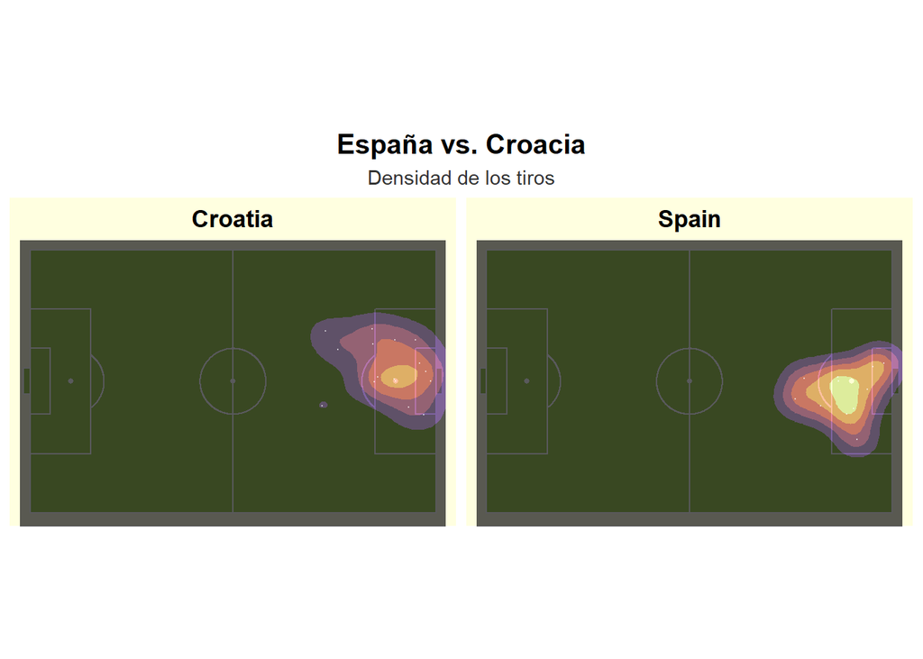

```r
df_tiros <- read_csv("tiros_espana.csv")

# Filtramos para el partido de Croacia usando su ID (3930160)
tiros_croacia <- df_tiros %>%
  filter(match_id == 3930160)%>%
  # Si nos fijamos en la base de datos, Lamine Yamal suele jugar en valores de y cercanos a 70, por lo que se deduce que la banda derecha del campo es la recta y=80, para que el gráfico sea totalmente representativo, hacemos coincidir dicha recta con la banda derecha del campo en el gráfico
  mutate(location_y_invertida = 80 - location_y)

# Construimos un mapa de calor con ggsoccer y geom_density_2d_filled()
ggplot(tiros_croacia, aes(x = location_x, y = location_y_invertida)) +

  # El campo reglamentario con las dimensiones de StatsBomb
  annotate_pitch(dimensions = pitch_statsbomb, fill ="darkolivegreen3", colour = "white") +

  # Niveles de densidad representados mediante áreas rellenas
  geom_density_2d_filled(alpha = 0.65, bins = 6) +

  # Marcas blancas sutiles de dónde ocurrió cada tiro
  geom_point(color = "white", alpha = 0.5, size = 0.1) +

  # Paleta de colores Magma para resaltar las "zonas calientes"
  scale_fill_viridis_d(option = "magma", direction = 1) +

  # Hacemos gráficos por equipo para comparar el dominio territorial
  facet_wrap(~team.name, ncol = 2) +

  coord_fixed(xlim = c(0, 120), ylim = c(0, 80)) +

  # Títulos y etiquetas
  labs(
    title = "España vs. Croacia",
    subtitle = "Densidad de los tiros",
    x = "Dirección de ataque (Izquierda a Derecha) ->",
    y = NULL
  ) +
  theme_pitch() +
  theme(
    panel.background = element_rect(fill = "lightyellow"),
    strip.background = element_rect(fill = "lightyellow"),
    strip.text = element_text(size = 13, face = "bold", color = "black"),
    plot.title = element_text(size = 15, face = "bold", hjust = 0.5, color = "black"),
    plot.subtitle = element_text(size = 11, hjust = 0.5, color = "gray20"),
    legend.position = "none"
  )
```

Los puntos blancos que se pueden apreciar en el gráfico representan cada intento de disparo. A pesar de que la cantidad total de tiros está bastante emparejada, el partido se decantó por la calidad individual del portero de “La Roja”, Unai Simón, atajando un penalti, y por una ejecución impecable de los disparos por parte de la selección española que terminaron en gol.

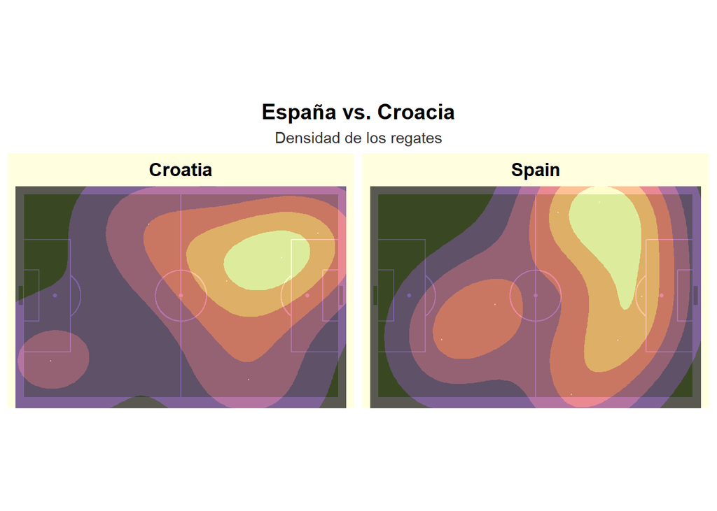

```r
# Filtramos para el partido de Croacia usando su ID (3930160) y filtramos por los regates exitosos
regates_croacia <- df_regates %>%
  filter(match_id == 3930160,dribble.outcome.name == "Complete")%>%
  # Si nos fijamos en la base de datos, Lamine Yamal suele jugar en valores de y cercanos a 70, por lo que se deduce que la banda derecha del campo es la recta y=80, para que el gráfico sea totalmente representativo, hacemos coincidir dicha recta con la banda derecha del campo en el gráfico
  mutate(location_y_invertida = 80 - location_y)

# Construimos un mapa de calor con ggsoccer y geom_density_2d_filled()
ggplot(regates_croacia, aes(x = location_x, y = location_y_invertida)) +

  # El campo reglamentario con las dimensiones de StatsBomb
  annotate_pitch(dimensions = pitch_statsbomb, fill ="darkolivegreen3", colour = "white") +

  # Niveles de densidad representados mediante áreas rellenas
  geom_density_2d_filled(alpha = 0.65, bins = 6) +

  # Marcas blancas sutiles de dónde ocurrió cada regate
  geom_point(color = "white", alpha = 0.5, size = 0.1) +

  # Paleta de colores Magma para resaltar las "zonas calientes"
  scale_fill_viridis_d(option = "magma", direction = 1) +

  # Hacemos gráficos por equipo para comparar el dominio territorial
  facet_wrap(~team.name, ncol = 2) +

  coord_fixed(xlim = c(0, 120), ylim = c(0, 80)) +

  # Títulos y etiquetas
  labs(
    title = "España vs. Croacia",
    subtitle = "Densidad de los regates",
    x = "Dirección de ataque (Izquierda a Derecha) ->",
    y = NULL
  ) +
  theme_pitch() +
  theme(
    panel.background = element_rect(fill = "lightyellow"),
    strip.background = element_rect(fill = "lightyellow"),
    strip.text = element_text(size = 13, face = "bold", color = "black"),
    plot.title = element_text(size = 15, face = "bold", hjust = 0.5, color = "black"),
    plot.subtitle = element_text(size = 11, hjust = 0.5, color = "gray20"),
    legend.position = "none"
  )
```

El mapa de calor de regates deja ver que la estrategia de la selección croata era concentrarlos por dentro, el bloque medio de España (con Rodri y los centrales) repelió con facilidad estas conducciones. Además, sus bandas aparecen prácticamente vacías en comparación con las de España, lo que se tradujo en un ataque previsible, lento y fácil de defender para los laterales españoles.

En definitiva, fue un partido parejo en trámites generales, pero la igualdad se rompió definitivamente con la ofensividad española. Croacia generó un juego plano, sin apenas verticalidad en la zona de tres cuartos de campo. Mientras tanto España ejecutó un ataque clínico, aprovechando la calidad de sus extremos, concentrando prácticamente todos sus disparos peligrosos en la zona del punto de penalti, maximizando así la probabilidad de gol.

Pasamos ahora a realizar un análisis análogo para el partido de cuartos de final contra Alemania.

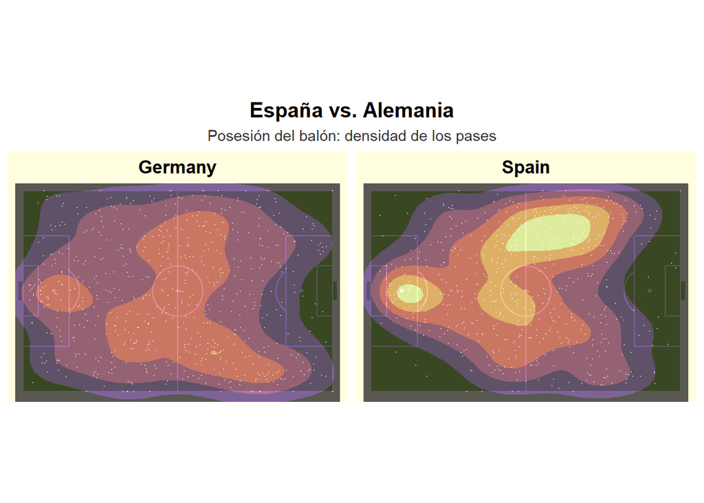

```r
# Filtramos para el partido de Alemania usando su ID (3942226)
pases_alemania <- df_pases %>%
  filter( match_id == 3942226)%>%
  # Si nos fijamos en la base de datos, Lamine Yamal suele jugar en valores de y cercanos a 70, por lo que se deduce que la banda derecha del campo es la recta y=80, para que el gráfico sea totalmente representativo, hacemos coincidir dicha recta con la banda derecha del campo en el gráfico
  mutate(location_y_invertida = 80 - location_y)

# Construimos un mapa de calor con ggsoccer y geom_density_2d_filled()
ggplot(pases_alemania, aes(x = location_x, y = location_y_invertida)) +

  # El campo reglamentario con las dimensiones de StatsBomb
  annotate_pitch(dimensions = pitch_statsbomb, fill ="darkolivegreen3", colour = "white") +

  # Niveles de densidad representados mediante áreas rellenas
  geom_density_2d_filled(alpha = 0.65, bins = 6) +

  # Marcas blancas sutiles de dónde ocurrió cada pase
  geom_point(color = "white", alpha = 0.5, size = 0.1) +

  # Paleta de colores Magma para resaltar las "zonas calientes"
  scale_fill_viridis_d(option = "magma", direction = 1) +

  # Hacemos gráficos por equipo para comparar el dominio territorial
  facet_wrap(~team.name, ncol = 2) +

  coord_fixed(xlim = c(0, 120), ylim = c(0, 80)) +

  # Títulos y etiquetas
  labs(
    title = "España vs. Alemania",
    subtitle = "Posesión del balón: densidad de los pases",
    x = "Dirección de ataque (Izquierda a Derecha) ->",
    y = NULL
  ) +
  theme_pitch() +
  theme(
    panel.background = element_rect(fill = "lightyellow"),
    strip.background = element_rect(fill = "lightyellow"),
    strip.text = element_text(size = 13, face = "bold", color = "black"),
    plot.title = element_text(size = 15, face = "bold", hjust = 0.5, color = "black"),
    plot.subtitle = element_text(size = 11, hjust = 0.5, color = "gray20"),
    legend.position = "none"
  )
```

El foco amarillo de España es una herradura perfecta que encierra a Alemania en su propio campo. El hecho de que la selección española tenga más volumen de pases aquí es consistente con la altura de las jugadas de España, moviendo el balón de lado a lado frente a un bloque alemán que se vio obligado a replegar y a perseguir sombras en algunas fases del partido. Asimismo podemos observar una gran cantidad de pases del combinado de Luis de la Fuente en área propia, mostrando que el conjunto español trata de sacar siempre el balón jugado, evitando regalar la posesión al rival con balones largos.

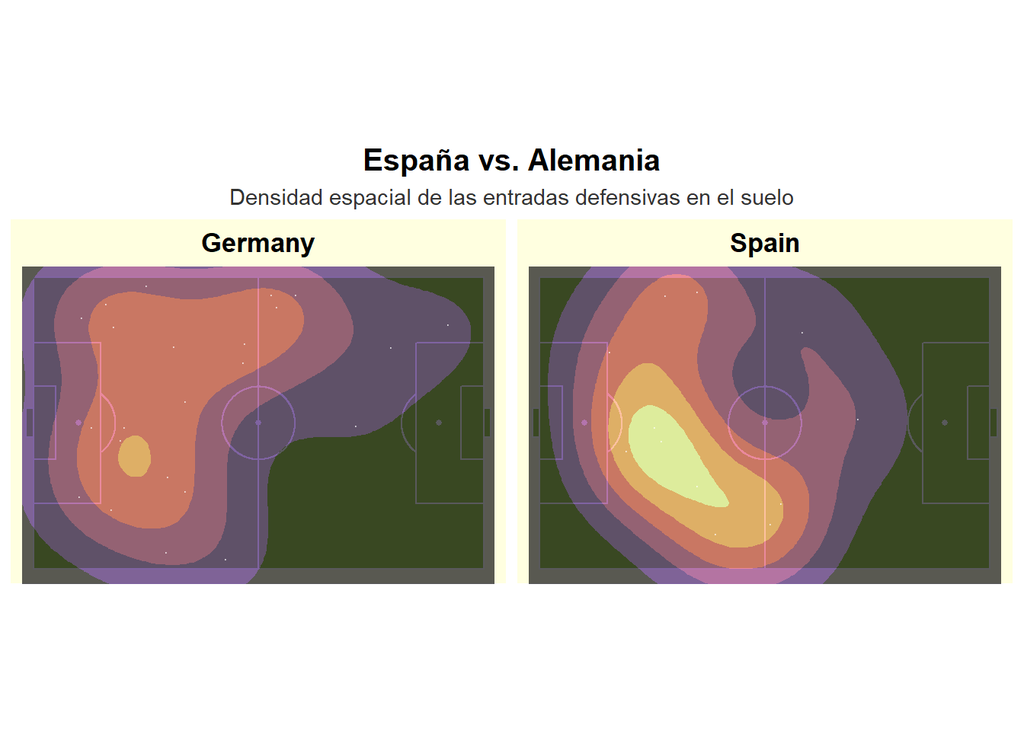

```r
# Filtramos para el partido de Alemania usando su ID (3942226) y filtramos por acciones defensivas en el suelo
duelos_alemania <- df_duelos %>%
  filter(match_id == 3942226, duel.type.name=="Tackle")%>%
  # Si nos fijamos en la base de datos, Lamine Yamal suele jugar en valores de y cercanos a 70, por lo que se deduce que la banda derecha del campo es la recta y=80, para que el gráfico sea totalmente representativo, hacemos coincidir dicha recta con la banda derecha del campo en el gráfico
  mutate(location_y_invertida = 80 - location_y)

# Construimos un mapa de calor con ggsoccer y geom_density_2d_filled()
ggplot(duelos_alemania, aes(x = location_x, y = location_y_invertida)) +

  # El campo reglamentario con las dimensiones de StatsBomb
  annotate_pitch(dimensions = pitch_statsbomb, fill ="darkolivegreen3", colour = "white") +

  # Niveles de densidad representados mediante áreas rellenas
  geom_density_2d_filled( alpha = 0.65, bins = 6) +

  # Marcas blancas sutiles de dónde ocurrió cada entrada
  geom_point(color = "white", alpha = 0.5, size = 0.1) +

  # Paleta de colores Magma para resaltar las "zonas calientes"
  scale_fill_viridis_d(option = "magma", direction = 1, ) +

  # Hacemos gráficos por equipo para comparar el dominio territorial
  facet_wrap(~team.name, ncol = 2) +

  coord_fixed(xlim = c(0, 120), ylim = c(0, 80)) +

  # Títulos y etiquetas
  labs(
    title = "España vs. Alemania",
    subtitle = "Densidad espacial de las entradas defensivas en el suelo",
    x = "Dirección de ataque (Izquierda a Derecha) ->",
    y = NULL
  ) +
  theme_pitch() + # Aplicamos el tema de campo de ggsoccer
  theme(
    panel.background = element_rect(fill = "lightyellow"),
    strip.background = element_rect(fill = "lightyellow"),
    strip.text = element_text(size = 13, face = "bold", color = "black"),
    plot.title = element_text(size = 15, face = "bold", hjust = 0.5, color = "black"),
    plot.subtitle = element_text(size = 11, hjust = 0.5, color = "gray20"),
    legend.position = "none"
  )
```

El foco denso de entradas defensivas deja entrever que el sistema de coberturas funcionó a la perfección. Al contar con mayor posesión del balón, “La Roja” se expuso a peligrosas contras de la selección alemana, cuando este equipo lograba robar e intentaba salir rápido por su carril izquierdo (el perfil de Sané), los defensores españoles mordieron con todo, yendo al suelo con una agresividad tremenda para cortar el peligro de raíz.

## 3.2. Conclusión del papel de España hasta cuartos

El camino de la selección española desde su debut en la fase de grupos hasta superar los cuartos de final de la Eurocopa 2024 representa una auténtica declaración de intenciones y madurez competitiva. Los datos espaciales y mapas de densidad permiten ver que el equipo de Luis de la Fuente dejó atrás el “estilo contemplativo”, transformándose en un equipo vertical y letal, exprimiendo sus virtudes al máximo. En definitiva, llegar a las semifinales eliminando a potencias como Italia y la anfitriona Alemania no fue producto de la casualidad, España firmó el papel de la selección más completa del torneo.

# 4. El Juego en Movimiento: Animación de Datos

Hasta ahora, hemos trabajado con gráficos estáticos que resumen mucha información en una sola imagen. Estas visualizaciones son útiles para comparar jugadores, ver tendencias o analizar el rendimiento de un equipo durante una competición. Sin embargo, cuando hablamos de fútbol, hay un aspecto clave que los gráficos estáticos no siempre logran mostrar: el movimiento.

Muchas acciones en un partido tienen un importante componente temporal. Un contraataque, una serie de pases o incluso la evolución de las estadísticas de un jugador a medida que avanza un torneo son ejemplos de situaciones donde no solo importa el resultado final, sino también cómo se llega a él. Aunque una imagen fija puede mostrar un momento de la situación, a menudo pierde parte de la historia detrás de ella.

Las animaciones permiten añadir esta dimensión temporal en la visualización de datos. Además de hacer los gráficos más atractivos, ofrecen una manera diferente de explorar la información. Permiten observar secuencias, ritmos y patrones que pueden pasar desapercibidos en una representación estática. En el ámbito deportivo, esto es especialmente interesante porque acerca el análisis de datos a la dinámica del juego.

Para ello, utilizamos el paquete gganimate, una extensión de ggplot2 que nos permite añadir movimiento a los gráficos. Continuamos con los mismos datos de la Eurocopa 2024, incorporando ahora el tiempo de forma explícita para poder observar no solo qué ocurrió, sino también cómo fueron desarrollándose algunas situaciones a lo largo de ese periodo.

Para materializar y exportar todas las visualizaciones dinámicas desarrolladas a lo largo de este capítulo, se utiliza la función animate(), que sirve como motor de renderizado de gganimate. Esta función permite calibrar el ritmo y la fluidez en pantalla mediante cuatro argumentos: nframes(define el número total de imágenes independientes generadas), fps (regula los fotogramas por segundo para adaptar la velocidad visual a la de la jugada), duration (fija la duración de la animación) y end_pause (congela estratégicamente el último fotograma para facilitar una interpretación final).

A continuación, nuestro objetivo es analizar los dos últimos partidos de “La Roja” en la Eurocopa 2024 a la vez que exploramos las funciones más destacadas del paquete elegido.

## 4.1. El factor tiempo y la evolución continua del xG

Comenzamos con una idea sencilla, pero muy importante en el fútbol: el tiempo no es un elemento secundario. Es la forma en la que el partido se organiza y cobra sentido.

Las acciones no aparecen aisladas. Se encadenan, se aceleran o se frenan, y esa dinámica acaba siendo tan relevante como el resultado final. Por eso, cuando trabajamos con datos temporales, no siempre basta con mirar el desenlace, a veces necesitamos entender cómo se ha ido construyendo.

En muchos casos, ese tiempo se comporta como una secuencia continua, en la que cada instante se apoya en el anterior. Esto permite leer los datos como un proceso que avanza de forma natural, casi como si siguiéramos el partido en directo.

### transition_reveal()

En este tipo de situaciones, transition_reveal() encaja especialmente bien. La idea de esta función consiste en construir una animación siguiendo el orden temporal de los datos en lugar de mostrar todos los puntos a la vez. Dicha animación no aparece completa desde el inicio, sino que se va formando paso a paso, manteniendo siempre lo que ya ha sido dibujado y respetando el orden en el que ocurren los eventos.

### El pulso del partido: España frente a Francia e Inglaterra

Para ver esto en contexto, analizamos la evolución de los goles esperados (xG) a favor y en contra de España en dos partidos de máxima exigencia en la Eurocopa: la semifinal frente a Francia y la final contra Inglaterra. El interés no está solo en el resultado final, sino en entender cómo se fue generando el peligro a lo largo del encuentro.

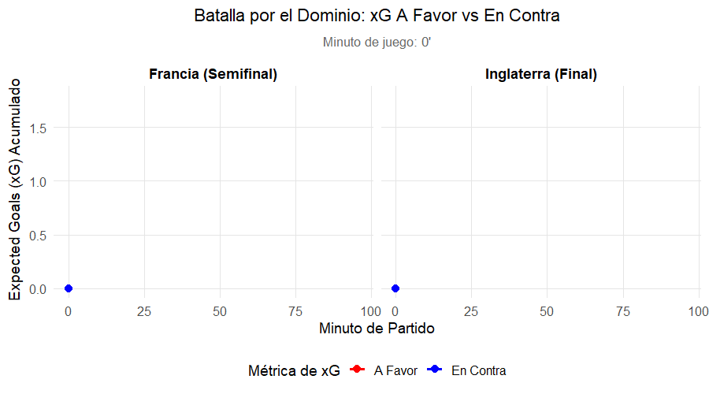

```r
# Importamos los dos archivos CSV que contienen los eventos de los tiros y los minutos de los partidos
datos_tiros <- read.csv("tiros_espana.csv", check.names = FALSE)
datos_duracion <- read.csv("duracion_partidos_espana.csv", check.names = FALSE)

# El nombre de los partidos viene con texto extra como "Spain vs France" o "England vs Spain"
# Usamos la función de limpiar texto para borrar esos añadidos y quitar los espacios en blanco sueltos
# De esta forma, en las etiquetas del gráfico solo se leerá el nombre limpio del rival
duracion_limpia <- datos_duracion %>%
  mutate(
    partido = gsub("Spain vs |vs Spain", "", partido),
    partido = trimws(partido)
  )

# Identificamos ahora los partidos en orden y filtramos las fases finales:
# Extraemos la lista única de los rivales tal y como aparecen ordenados en el archivo de duración original
orden_partidos_real <- unique(duracion_limpia$partido)

# Como el archivo de tiros tiene todos los partidos juntos, empleamos match_id para que R sepa cuándo cambia de uno a otro.
tiros_procesados <- datos_tiros %>%
  # Filtramos directamente por los números de identificación de la semi y la final
  filter(match_id %in% c(3942752, 3943043)) %>%

  # Le asignamos su nombre correspondiente a cada ID
  mutate(
    partido = case_when(
      match_id == 3942752 ~ "France",
      match_id == 3943043 ~ "England"
    ),
    # Creamos la etiqueta de si el tiro es de España o del rival
    tipo_xg = ifelse(possession_team.name == "Spain", "A Favor", "En Contra")
  ) %>%

  # Agrupamos por partido y por bando para ordenar los tiros por minuto y segundo exactos
  # Luego acumulamos los valores de xG para ir sumando el peligro total a lo largo del encuentro
  group_by(partido, tipo_xg) %>%
  arrange(minute, second, .by_group = TRUE) %>%
  mutate(xg_acumulado = cumsum(shot.statsbomb_xg)) %>%
  ungroup()

# Buscamos la duración máxima real entre los dos partidos elegidos (Francia e Inglaterra)
# Redondeamos ese número hacia arriba para fijar el límite común del eje X en 96 minutos exactos
tope_minuto_finales <- duracion_limpia %>%
  filter(partido %in% c("France", "England")) %>%
  pull(duracion_minutos) %>%
  max(na.rm = TRUE) %>%
  ceiling()

# Construimos una cuadrícula temporal vacía que combine cada partido, tipo de xG y todos los minutos del 0 al 96
# Esto es crucial para que gganimate tenga exactamente la misma cantidad de fotogramas en ambos lados de la pantalla
parrilla_tiempo <- expand.grid(
  partido = c("France", "England"),
  tipo_xg = c("A Favor", "En Contra"),
  minute = 0:tope_minuto_finales
)

# Unimos la cuadrícula vacía con los datos reales que procesamos de los tiros
datos_completos <- parrilla_tiempo %>%
  left_join(
    tiros_procesados %>% select(partido, tipo_xg, minute, xg_acumulado),
    by = c("partido", "tipo_xg", "minute")
  ) %>%
  left_join(duracion_limpia, by = "partido") %>%

  # Como no hay tiros en todos los minutos, la columna de xG acumulado se llena de huecos vacíos
  # Hacemos que la línea mantenga el valor del último tiro registrado hasta que ocurra el siguiente disparo
  # Si al principio del partido no hay tiros, nos aseguramos de empezar la línea en 0 goles esperados
  group_by(partido, tipo_xg) %>%
  arrange(minute) %>%
  fill(xg_acumulado, .direction = "down") %>%
  mutate(xg_acumulado = replace_na(xg_acumulado, 0)) %>%

  # Aplicamos el truco del corte: si el minuto de la cuadrícula es mayor que los minutos reales que duró el partido,
  # forzamos un valor vacío. Así la animación de Inglaterra frena en seco y no sigue dibujando una línea plana artificial
  mutate(
    xg_acumulado = ifelse(minute > duracion_minutos, NA, xg_acumulado)
  ) %>%
  ungroup()

# Traducimos, seguidamente, a español los nombres de los rivales para los títulos de los gráficos:
# Transformamos la columna partido en un factor para elegir el orden de visualización de los paneles en la pantalla
datos_completos <- datos_completos %>%
  mutate(
    partido = factor(partido, levels = c("France", "England"), labels = c("Francia (Semifinal)", "Inglaterra (Final)"))
  )

# Creamos el gráfico base y añadimos la animación continua
grafico_base <- ggplot(datos_completos, aes(x = minute, y = xg_acumulado, color = tipo_xg, group = tipo_xg)) +

  # Utilizamos geom_step() para pintar la línea con un efecto de escalera o peldaños
  # El xG acumulado aumenta con cada disparo, por lo que geom_step() permite representar estos cambios de forma escalonada
  geom_step(linewidth = 1.2) +
  geom_point(size = 3) +

  # Realizamos las dos gráficas a la vez (vs Francia y vs Inglaterra), gracias a la siguiente función
  facet_wrap(~partido) +

  # Asignamos de forma manual el color rojo para España y el color azul para los rivales
  scale_color_manual(values = c("A Favor" = "red", "En Contra" = "blue")) +

  # Configuramos todos los textos del gráfico. En el subtítulo añadimos el truco de frame_along
  # frame_along se actualiza durante la animación y permite mostrar el minuto correspondiente en cada fotograma
  labs(
    title = "Batalla por el Dominio: xG A Favor vs En Contra",
    subtitle = "Minuto de juego: {round(frame_along, 0)}'",
    x = "Minuto de Partido",
    y = "Expected Goals (xG) Acumulado",
    color = "Métrica de xG",
  ) +
  theme_minimal(base_size = 14) +
  theme(
    plot.background = element_rect(fill = "white", color = NA),
    plot.title = element_text(face = "bold", size = 16, hjust = 0.5, color = "black"),
    plot.subtitle = element_text(size = 12, hjust = 0.5, face = "italic", color = "gray40"),
    strip.text = element_text(face = "bold", size = 13, color = "black"),
    legend.position = "bottom",
    panel.grid.minor = element_blank(),
    panel.grid.major = element_line(color = "gray90")
  ) +

  # Activamos la función de transición indicando que el gráfico se tiene que descubrir de izquierda a derecha siguiendo la variable de los minutos
  transition_reveal(minute)

# Compilamos y generamos finalmente el archivo GIF:
# Pasamos el gráfico base por la función animate para procesar todos los fotogramas y unirlos en el archivo definitivo
animacion_xg <- animate(
  grafico_base,
  nframes = 140,      # Definimos el número total de imágenes que va a tener la animación
  fps = 12,           # Marcamos la velocidad fijando cuántos fotogramas se reproducen por cada segundo de vídeo
  end_pause = 35,     # Añadimos una pausa al final de la animación para que se pueda analizar el resultado definitivo
  width = 900,        # Le damos un ancho generoso para asegurarnos de que los dos paneles se vean amplios y limpios
  height = 500,
  units = "px",
  res = 100,
  renderer = gifski_renderer() # Usamos el motor de renderizado de gifski para que el archivo tenga la máxima calidad posible
)
animacion_xg
```

Al observar esta animación en su desarrollo temporal, podemos analizar los patrones y momentos críticos de ambos encuentros.

En la semifinal, la animación muestra que Francia golpeó primero en los goles esperados. Su línea azul sufre un salto vertical temprano cerca del minuto 9 por un gol de cabeza en la portería española. Lo más interesante de la animación es que, si observamos la línea roja en el minuto 20, con el golazo de España, esta apenas sufre un leve incremento. Este hecho explica perfectamente la naturaleza del xG: el gol de Lamine desde fuera del área tenía una probabilidad matemática cercana a cero, debido a la enorme distancia y la oposición defensiva. España se puso por delante en el marcador real no por acumular muchas ocasiones claras, sino por una efectividad individual extraordinaria que desafió las probabilidades estimadas del modelo histórico. A partir del minuto 30, el gráfico dinámico muestra cómo la línea roja de España se vuelve totalmente horizontal, lo que significa que renunció a atacar para proteger el resultado. Es por eso que la línea azul de Francia experimenta pequeños escalones muy espaciados en el tiempo, por su intención de lograr el empate.

En la final, hasta el minuto 45 no se producen ocasiones que generen un cambio excesivamente brusco en los goles esperados a favor de ningún conjunto. Esto indica el gran trabajo de los defensas, los cuales permitieron que los pocos tiros de la primera parte se realizaran desde zonas muy escoradas, teniendo un xG bajo. Después del descanso, la línea roja rompe con esta tendencia mediante una sucesión rápida de escalones. España logró marcar rápidamente un gol y la pendiente acumulada sube de forma abrumadora hasta rozar un xG de 1.8. De igual forma, podemos apreciar que Inglaterra tuvo un chispazo después del minuto 75 generado por el empate de Cole Palmer. Aún así la animación demuestra que España mantuvo su constancia generadora, sumando un último escalón en el minuto 86 gracias a una asistencia de Cucurella milimétrica que generó un remate con una alta probabilidad de conversión, el gol de Oyarzabal.

## 4.2. El torneo por bloques: Estructura de partidos y rankings

Cuando pasamos de analizar un solo partido a mirar todo un torneo, el tiempo deja de sentirse como algo continuo, dividiéndose en bloques. Cada encuentro tiene su propio ritmo lo que hace que el torneo funcione casi como una suma de pequeñas escenas.

Esa división cambia también la forma de leer los datos. Ya no importa solo cómo evoluciona una métrica, sino cómo se reorganizan los papeles dentro del equipo a medida que avanzan los partidos.

### transition_states(), ease_aes(), view_follow()

En gganimate, estos bloques se representan como estados. Cada estado es una versión concreta del sistema en un momento determinado, en este caso, cada partido de la Eurocopa. La función transition_states() es la que permite pasar de un estado a otro de forma ordenada, haciendo que la animación avance por los distintos partidos.

Para que ese cambio entre estados no resulte abrupto, se puede ajustar el ritmo de transición. Con ease_aes se mantiene una velocidad constante entre partidos, evitando aceleraciones o frenadas en la animación. Además, view_follow() hace que la visualización se adapte automáticamente a los cambios en los valores, siguiendo el crecimiento de las barras y manteniendo siempre el foco en la comparación entre jugadores.

### Duelos y disputas ganadas por España vs Francia e Inglaterra

Con esto construimos un gráfico que muestra la evolución acumulada de los duelos físicos y disputas ganadas por los futbolistas de España a lo largo de la semifinal y final del torneo. La idea es sumamente atractiva: ver en tiempo real qué jugadores asumieron el peso defensivo y el dominio de los balones divididos en cada tramo del partido, identificando quiénes ganaron más batallas individuales a medida que el cansancio hacía mella en el encuentro.

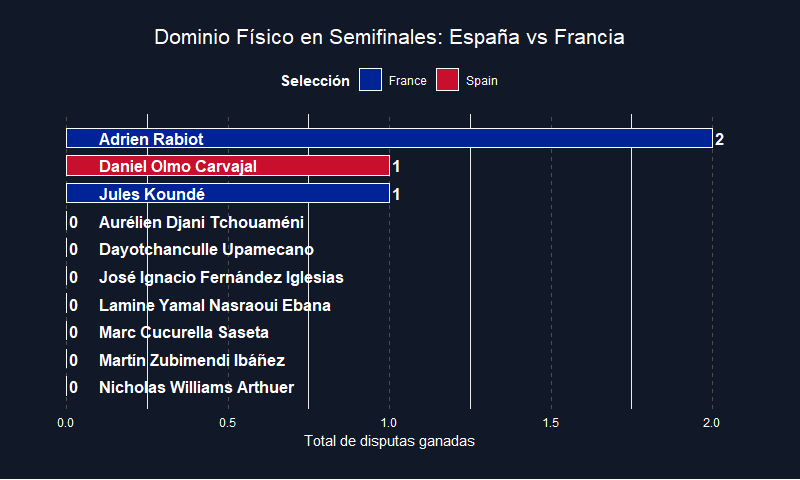

```r
# Cargamos el dataset de duelos
duelos_brutos <- read.csv("duelos_espana.csv")

# Filtramos para la Semifinal incluyendo ambos equipos
duelos_semis <- duelos_brutos %>%
  filter(
    match_id == 3942752,
    duel.outcome.name %in% c("Won", "Success In Play")
  ) %>%
  mutate(
    bloque_tiempo = case_when(
      minute <= 15 ~ "Minuto 00-15",
      minute <= 30 ~ "Minuto 16-30",
      minute <= 45 ~ "Minuto 31-45",
      minute <= 60 ~ "Minuto 46-60",
      minute <= 75 ~ "Minuto 61-75",
      TRUE         ~ "Minuto 76-Fin"
    )
  )

# Calculamos la acumulación de duelos ganados por jugador
tabla_semis <- duelos_semis %>%
  group_by(player.name, team.name, bloque_tiempo) %>%
  summarise(duelos_en_bloque = n(), .groups = "drop") %>%
  complete(nesting(player.name, team.name), bloque_tiempo, fill = list(duelos_en_bloque = 0)) %>%
  arrange(player.name, bloque_tiempo) %>%
  group_by(player.name) %>%
  mutate(duelos_acumulados = cumsum(duelos_en_bloque)) %>%
  ungroup()

# Asignamos ranking dinámico por bloque de tiempo y filtramos el Top 10
ranking_semis <- tabla_semis %>%
  group_by(bloque_tiempo) %>%
  mutate(rank = rank(-duelos_acumulados, ties.method = "first")) %>%
  ungroup() %>%
  filter(rank <= 10)

# Definimos los colores de las selecciones
colores_semis <- c("Spain" = "#c8102e", "France" = "#002395")

# Construcción de la animación para la semifinal
grafico_semis <- ggplot(ranking_semis, aes(x = rank, y = duelos_acumulados, fill = team.name, group = player.name)) +
  geom_col(width = 0.7, show.legend = TRUE, color = "white") +
  geom_text(aes(y = 0.1, label = player.name), hjust = 0, color = "white", fontface = "bold", size = 4) +
  geom_text(aes(y = duelos_acumulados, label = as.character(duelos_acumulados)), hjust = -0.3, color = "white", fontface = "bold", size = 4) +
  coord_flip(clip = "off") +
  scale_x_reverse() +
  scale_fill_manual(values = colores_semis, name = "Selección") +
  labs(
    title = "Dominio Físico en Semifinales: España vs Francia",
    x = "", y = "Total de disputas ganadas"
  ) +
  theme_minimal() +
  theme(
    plot.background = element_rect(fill = "#111827", color = NA),
    panel.background = element_rect(fill = "#111827", color = NA),
    panel.grid.major.y = element_blank(),
    panel.grid.minor.y = element_blank(),
    panel.grid.major.x = element_line(color = "gray30", linetype = "dashed"),
    plot.title = element_text(color = "white", face = "bold", size = 15, hjust = 0.5),
    axis.text.y = element_blank(),
    axis.text.x = element_text(color = "white"),
    axis.title.x = element_text(color = "white", face = "bold"),
    legend.text = element_text(color = "white"),
    legend.title = element_text(color = "white", face = "bold"),
    legend.position = "top",
    plot.margin = margin(20, 40, 20, 20)
  ) +
  transition_states(bloque_tiempo, transition_length = 4, state_length = 2) +
  ease_aes('linear') +
  view_follow(fixed_x = TRUE)

# Generamos el primer gif
animate(grafico_semis, nframes = 100, fps = 12, width = 800, height = 480, units = "px", res = 100, renderer = gifski_renderer("duelos_semis.gif"))
```

La transición de los estados temporales en este gráfico muestra la gran exigencia del encuentro. En la primera parte del choque, se demostró la capacidad física del centro del campo francés, ganando Rabiot y Tchouameni 3 duelos cada uno. Mientras tanto, en el tramo final los mediocentros de Francia se estancaron mientras que la selección española mantuvo una aportación coral, donde desde los delanteros hasta los zagueros siguieron sumando disputas ganadas hasta el pitido final. Mediante esta animación podemos concluir que España asfixió y desarmó el centro del campo de “Les Bleus” mediante del desgaste continuo.

Veamos ahora este mismo gráfico pero en este caso relativo a la final ante Inglaterra.

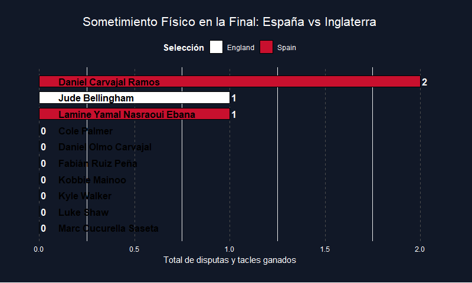

```r
# Filtramos para la Final incluyendo ambos equipos
duelos_final <- duelos_brutos %>%
  filter(
    match_id == 3943043,
    duel.outcome.name %in% c("Won", "Success In Play")
  ) %>%
  mutate(
    bloque_tiempo = case_when(
      minute <= 15 ~ "Minuto 00-15",
      minute <= 30 ~ "Minuto 16-30",
      minute <= 45 ~ "Minuto 31-45",
      minute <= 60 ~ "Minuto 46-60",
      minute <= 75 ~ "Minuto 61-75",
      TRUE         ~ "Minuto 76-Fin"
    )
  )

# Calculamos la acumulación de duelos ganados por jugador
tabla_final <- duelos_final %>%
  group_by(player.name, team.name, bloque_tiempo) %>%
  summarise(duelos_en_bloque = n(), .groups = "drop") %>%
  complete(nesting(player.name, team.name), bloque_tiempo, fill = list(duelos_en_bloque = 0)) %>%
  arrange(player.name, bloque_tiempo) %>%
  group_by(player.name) %>%
  mutate(duelos_acumulados = cumsum(duelos_en_bloque)) %>%
  ungroup()

# Asignamos ranking dinámico por bloque de tiempo y filtramos el Top 10
ranking_final <- tabla_final %>%
  group_by(bloque_tiempo) %>%
  mutate(rank = rank(-duelos_acumulados, ties.method = "first")) %>%
  ungroup() %>%
  filter(rank <= 10)

# Definimos los colores para los equipos
colores_final <- c("Spain" = "#c8102e", "England" = "white")

# Construcción de la animación para la final
grafico_final <- ggplot(ranking_final, aes(x = rank, y = duelos_acumulados, fill = team.name)) +
  geom_col(width = 0.7, show.legend = TRUE, color = "black") +
  geom_text(aes(y = 0.1, label = player.name), hjust = 0, color = "black", fontface = "bold", size = 4) +
  geom_text(aes(y = duelos_acumulados, label = as.character(duelos_acumulados)), hjust = -0.3, color = "white", fontface = "bold", size = 4) +
  coord_flip(clip = "off") +
  scale_x_reverse() +
  scale_fill_manual(values = colores_final, name = "Selección") +
  labs(
    title = "Sometimiento Físico en la Final: España vs Inglaterra",
    x = "", y = "Total de disputas y tacles ganados"
  ) +
  theme_minimal() +
  theme(
    plot.background = element_rect(fill = "#111827", color = NA),
    panel.background = element_rect(fill = "#111827", color = NA),
    panel.grid.major.y = element_blank(),
    panel.grid.minor.y = element_blank(),
    panel.grid.major.x = element_line(color = "gray30", linetype = "dashed"),
    plot.title = element_text(color = "white", face = "bold", size = 15, hjust = 0.5),
    plot.subtitle = element_text(color = "#00f0ff", size = 12, face = "italic", hjust = 0.5),
    axis.text.y = element_blank(),
    axis.text.x = element_text(color = "white"),
    axis.title.x = element_text(color = "white", face = "bold"),
    legend.text = element_text(color = "white"),
    legend.title = element_text(color = "white", face = "bold"),
    legend.position = "top",
    plot.margin = margin(20, 40, 20, 20)
  ) +
  transition_states(bloque_tiempo, transition_length = 4, state_length = 2) +
  ease_aes('linear') +
  view_follow(fixed_x = TRUE)

# Generamos el segundo GIF
animate(grafico_final, nframes = 100, fps = 12, width = 800, height = 480, units = "px", res = 100, renderer = gifski_renderer("duelos_final.gif"))
```

A diferencia de la semifinal contra Francia, donde España logró imponer una superioridad física en el tramo final, la gráfica de la final frente a Inglaterra revela un escenario de auténtico equilibrio y desgaste mutuo. Inglaterra opuso una resistencia feroz comandada por el despliegue de Bellingham, pero España contrarrestó esa fuerza mediante el orden táctico de Carvajal y el pulmón inagotable de Fabián Ruiz.

Las herramientas de animación aplicadas confirman que España se coronó campeona de Europa sabiendo sufrir, igualando el listón físico de una de las selecciones más potentes del mundo y manteniendo la lucidez defensiva hasta el último segundo de cada encuentro.

## 4.3. La persistencia del pasado: El rastro de las jugadas

Hasta ahora hemos visto cómo el tiempo puede representarse de forma continua o dividida en etapas. No obstante, todavía falta una tercera forma de entenderlo: cuando el pasado no desaparece, sino que se queda en el gráfico.

En el fútbol, esto es bastante natural. Una jugada no se entiende solo por el pase actual, sino por todo lo que ha ido ocurriendo antes. La posición del balón, los apoyos previos, los movimientos que han abierto líneas de pase,…, todo eso forma parte de la lectura de la acción.

### shadow_mark()

La librería gganimate permite capturar esta persistencia mediante la función shadow_mark(). A diferencia de otros operadores de transición, esta función no destruye la información de los fotogramas anteriores al avanzar el cronómetro. Por el contrario, retiene los elementos previos en pantalla aplicando una opacidad atenuada, configurando un rastro geométrico que acumula la historia del movimiento.

### Análisis Geoespacial y Simulación de Jugadas en la Semifinal: España vs. Francia

Para aterrizar este concepto en un contexto colectivo de máxima exigencia, analizamos la evolución espacial de los pases completados por España y Francia en la semifinal. Mediante una cuadrícula bivariada (geom_bin2d()) y el rastro permanente de shadow_mark(), transformamos las coordenadas de finalización de los pases en un mapa de densidad dinámico y acumulativo. Esto nos permite visualizar, minuto a minuto y mediante facetas comparativas, cómo ambos países fueron conquistando, habitando o perdiendo terreno sobre el césped a lo largo de los 90 minutos.

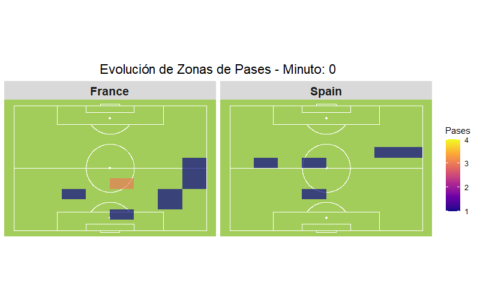

```r
# Cargamos los datos
datos_pases <- read_csv("pases_espana.csv")

# Filtramos para el partido de semifinales y pases completados
pases_semis <- datos_pases %>%
  filter(
    match_id == 3942752,
    team.name %in% c("Spain", "France"),
    pass.outcome.name == "Complete" | is.na(pass.outcome.name)
  ) %>%
  mutate(minute = as.integer(minute))

# Creamos el gráfico usando geom_bin2d
grafico_base <- ggplot(data = pases_semis, aes(x = pass_end_x, y = pass_end_y)) +
  # Campo de fútbol oficial de StatsBomb de fondo
  annotate_pitch(
    dimensions = pitch_statsbomb,
    fill = "darkolivegreen3",
    colour = "white"
  ) +
  # Cuadrícula estática de conteo de pases para evitar parpadeos
  geom_bin2d(
    aes(group = team.name),
    binwidth = c(10, 10),
    alpha = 0.7
  ) +
  # Facet para separar y comparar España y Francia cara a cara
  facet_wrap(~team.name) +
  coord_flip(xlim = c(0, 120), ylim = c(0, 80)) +
  scale_fill_viridis_c(option = "plasma", name = "Pases") +
  theme_pitch() +
  theme(
    panel.background = element_rect(fill = "darkolivegreen3"),
    plot.background = element_rect(fill = "white"),
    strip.text = element_text(size = 14, face = "bold"),
    plot.title = element_text(size = 16, face = "bold", hjust = 0.5),
    legend.position = "right"
  )

# Configuramos la animación temporal
animacion_mapa <- grafico_base +
  labs(title = "Evolución de Zonas de Pases - Minuto: {frame_time}") +
  transition_time(minute) +
  shadow_mark(alpha = 0.3, past = TRUE, future = FALSE) # Mantiene el histórico del mapa de calor

# Renderizamos y guardamos el GIF
animate(
  animacion_mapa,
  nframes = max(pases_semis$minute) - min(pases_semis$minute) + 1,
  fps = 4,
  width = 800,
  height = 500,
  units = "px",
  res = 100,
  renderer = gifski_renderer("mapa_calor_fijo.gif")
)
```

El análisis secuencial de la densidad de pases a lo largo de la segunda mitad desvela de forma contundente cómo se inclinó la balanza táctica a favor de la Selección Española:

Si observamos la evolución del partido, el mapa de España muestra cómo la selección española centra sus pases en zonas cercanas a la portería contaria, sobre todo en la primera mitad del encuentro. Esta distribución espacial muestra que España logró asentar su juego de posición en el último tercio del campo, acumulando un volumen elevado de pases completados en la frontal del área francesa en el tramo decisivo del partido. Esta cantidad de pases disminuye relativamente en algunos momentos de la segunda parte debido a la búsqueda del empate por parte de la selección gala con su intento de dominio en el campo contrario.

En contraposición, el mapa de Francia desvela un relativo estancamiento en la primera parte. A lo largo de esta mitad las zonas de mayor densidad de pases se concentran cerca de su propio campo. A medida que avanza el cronómetro, se aprecia que Francia trata de conectar una mayor cantidad de pases cerca del área de España, buscando así marcar un gol para al menos llegar a una prórroga. Sin embargo, sus ataques quedan reducidos en múltiples ocasiones a tímidas combinaciones en las bandas, evidenciando que el bloque defensivo español los mantuvo relativamente alejados de las zonas de peligro.

Mediante este análisis podemos ver que España logró acaparar la posesión del balón, desgastando el centro del campo francés en la mayoría del partido. Pese a esto, la necesidad de buscar un gol hizo que el conjunto galo se volcara al ataque en la segunda mitad, llevando así a una superioridad en los goles esperados y en ciertos momentos en la creación ofensiva, obligando a España a tocar algo más atrás. Con esto, si algo nos queda claro es la igualdad del partido, con un encuentro que podría haberse decantado para cualquiera de los dos lados. No obstante, es en esta clase de encuentros cuando una genialidad acaba por inclinar la balanza, en este caso fue el gol de la joven estrella de la selección, Lamine Yamal.

```r
# Usamos una función para generar la trayectoria del balón para cada pase y cada conducción
generar_tramo_balon <- function(x_init, y_init, x_end, y_end, duration) {
  tibble(
    ball_x = seq(x_init, x_end, length.out = duration),
    ball_y = seq(y_init, y_end, length.out = duration)
  )
}

# Generamos las distintas trayectorias (haciendo uso de los datos de nuestra base)
t1  <- generar_tramo_balon(6.0, 38.8, 17.8, 27.5, duration = 15)  # Unai Simón -> Nacho
c1  <- generar_tramo_balon(17.8, 27.5, 31.7, 28.0, duration = 20)
t2  <- generar_tramo_balon(31.7, 28.0, 30.7, 57.3, duration = 18) # Nacho -> Laporte
c2  <- generar_tramo_balon(30.7, 57.3, 32.2, 56.1, duration = 10)
t3  <- generar_tramo_balon(32.2, 56.1, 40.7, 35.9, duration = 16) # Laporte -> Nacho
c3  <- generar_tramo_balon(40.7, 35.9, 47.8, 27.5, duration = 20)
t4  <- generar_tramo_balon(47.8, 27.5, 54.8, 48.9, duration = 16) # Nacho -> Rodri
c4  <- generar_tramo_balon(54.8, 48.9, 62.9, 58.4, duration = 22)
t5  <- generar_tramo_balon(62.9, 58.4, 74.7, 75.8, duration = 22) # Rodri -> Cucurella
c5  <- generar_tramo_balon(74.7, 75.8, 75.4, 75.6, duration = 4)
t6  <- generar_tramo_balon(75.4, 75.6, 60.7, 73.9, duration = 16) # Cucurella -> Rodri
c6  <- generar_tramo_balon(60.7, 73.9, 56.2, 73.4, duration = 12)
t7  <- generar_tramo_balon(56.2, 73.4, 46.7, 55.3, duration = 18) # Rodri -> Laporte
c7  <- generar_tramo_balon(46.7, 55.3, 45.3, 44.4, duration = 20)
t8  <- generar_tramo_balon(45.3, 44.4, 51.5, 31.1, duration = 18) # Laporte -> Nacho
c8  <- generar_tramo_balon(51.5, 31.1, 54.5, 30.8, duration = 6)
t9  <- generar_tramo_balon(54.5, 30.8, 80.0, 39.2, duration = 24) # Nacho -> Dani Olmo
c9  <- generar_tramo_balon(80.0, 39.2, 85.3, 45.5, duration = 16)
t10 <- generar_tramo_balon(85.3, 45.5, 89.5, 36.8, duration = 22) # Dani Olmo -> Morata

# Generamos por separado las trayectorias de Lamine, solo tenemos la ubicación de su tiro final así que para el resto de la trayectoria hacemos una suposición según el vídeo real del gol

# El último pase a Morata acaba con un despeje del francés Saliba así que generamos la trayectoria asociada
t_despeje    <- generar_tramo_balon(89.5, 36.8, 84.0, 30.8, duration = 16)
# Generamos la trayectoria de la conducción de Lamine
t_conduccion <- generar_tramo_balon(84.0, 30.8, 89.0, 33.5, duration = 24)
# Generamos la trayectoria del último amago que hace Lamine para quitarse a Rabiot de encima y disparar con su zurda
t_amago      <- generar_tramo_balon(89.0, 33.5, 93.2, 32.9, duration = 18)

# Generamos la trayectoria del disparo que acaba en gol
X_tiro <- seq(93.2, 120.0, length.out = 30)
# Normalizamos la distancia para así generar un número de 0 a 1
t_norm <- (X_tiro - 93.2) / (120.0 - 93.2)
# Usamos t_norm para generar una parábola del balón que acaba en la portería
Y_tiro <- 32.9 + 17.6 * t_norm - 8.0 * (t_norm^2)
t_disparo <- tibble(ball_x = X_tiro, ball_y = Y_tiro)

# Generamos una base de datos adicional con las trayectorias
balon_completo <- bind_rows(
  t1, c1, t2, c2, t3, c3, t4, c4, t5, c5, t6, c6, t7, c7, t8, c8, t9, c9, t10,
  t_despeje, t_conduccion, t_amago, t_disparo
) %>% mutate(frame_id = row_number())

# Usamos una variable auxiliar para saber los frames que necesitaremos en nuestro  gif
total_frames <- nrow(balon_completo)

# Según la duración designada para cada evento generamos una variable auxiliar para luego usarlo para representar las conducciones de los jugadores
f_t1  <- 15;          f_c1  <- f_t1 + 20; f_t2  <- f_c1 + 18;  f_c2  <- f_t2 + 10
f_t3  <- f_c2 + 16;   f_c3  <- f_t3 + 20; f_t4  <- f_c3 + 16;  f_c4  <- f_t4 + 22
f_t5  <- f_c4 + 22;   f_c5  <- f_t5 + 4;  f_t6  <- f_c5 + 16;  f_c6  <- f_t6 + 12
f_t7  <- f_c6 + 18;   f_c7  <- f_t7 + 20; f_t8  <- f_c7 + 18;  f_c8  <- f_t8 + 6
f_t9  <- f_c8 + 24;   f_c9  <- f_t9 + 16; f_t10 <- f_c9 + 22; f_desp  <- f_t10 + 16
f_cond  <- f_desp + 24; f_amago <- f_cond + 18

# Creamos una función para obtener la posición de los jugadores
obtener_posiciones_jugadores <- function(f) {
  # Generamos la posición inicial de cada jugador español
  espana <- tibble(
    no = c("23", "4", "14", "16", "24", "10", "7", "19"),
    x  = c(6.0, 17.8, 30.7, 54.8, 74.7, 80.0, 89.5, 84.0),
    y  = c(38.8, 27.5, 57.3, 48.9, 75.8, 39.2, 39.9, 27.8),
    team = "España"
  )
  # Nuestra idea basicamente es que cada jugador se vaya moviendo conduciendo el balón cuando vayan a realizar un pase desde donde reciba el balón hasta donde dé el pase y se mueva también cuando tenga que recibir un pase en un lugar distinto al que está, para esto echamos mano de las variables anteriormente generadas f_t para así poder generar el movimiento en el momento adecuado, ya sea cuando reciba el pase para conducir o cuando acabe de darlo para ir a recibir el siguiente pase. Usaremos una variable auxiliar, pct para generar números entre 0 y 1 para que así el movimiento sea continuo, desde que da el pase hasta que lo reciba y el jugador no se quede quieto en ningún momento.

  # Generamos el movimiento de Nacho
  if (f <= f_t1) {
    espana$x[espana$no == "4"] <- 17.8; espana$y[espana$no == "4"] <- 27.5
  } else if (f > f_t1 && f <= f_c1) {
    espana$x[espana$no == "4"] <- balon_completo$ball_x[f]; espana$y[espana$no == "4"] <- balon_completo$ball_y[f]
  } else if (f > f_c1 && f <= f_t3) {
    pct <- (f - f_c1) / (f_t3 - f_c1)
    espana$x[espana$no == "4"] <- 31.7 + (40.7 - 31.7) * pct; espana$y[espana$no == "4"] <- 28.0 + (35.9 - 28.0) * pct
  } else if (f > f_t3 && f <= f_c3) {
    espana$x[espana$no == "4"] <- balon_completo$ball_x[f]; espana$y[espana$no == "4"] <- balon_completo$ball_y[f]
  } else if (f > f_c3 && f <= f_t8) {
    pct <- (f - f_c3) / (f_t8 - f_c3)
    espana$x[espana$no == "4"] <- 47.8 + (51.5 - 47.8) * pct; espana$y[espana$no == "4"] <- 27.5 + (31.1 - 27.5) * pct
  } else if (f > f_t8 && f <= f_c8) {
    espana$x[espana$no == "4"] <- balon_completo$ball_x[f]; espana$y[espana$no == "4"] <- balon_completo$ball_y[f]
  } else {
    espana$x[espana$no == "4"] <- 54.5; espana$y[espana$no == "4"] <- 30.8
  }
```

```r
  # Generamos el movimiento de Laporte
  if (f <= f_t2) {
    espana$x[espana$no == "14"] <- 30.7; espana$y[espana$no == "14"] <- 57.3
  } else if (f > f_t2 && f <= f_c2) {
    espana$x[espana$no == "14"] <- balon_completo$ball_x[f]; espana$y[espana$no == "14"] <- balon_completo$ball_y[f]
  } else if (f > f_c2 && f <= f_t7) {
    pct <- (f - f_c2) / (f_t7 - f_c2)
    espana$x[espana$no == "14"] <- 32.2 + (46.7 - 32.2) * pct; espana$y[espana$no == "14"] <- 56.1 + (55.3 - 56.1) * pct
  } else if (f > f_t7 && f <= f_c7) {
    espana$x[espana$no == "14"] <- balon_completo$ball_x[f]; espana$y[espana$no == "14"] <- balon_completo$ball_y[f]
  } else {
    espana$x[espana$no == "14"] <- 45.3; espana$y[espana$no == "14"] <- 44.4
  }

  # Generamos el movimiento de Rodri
  if (f <= f_t4) {
    espana$x[espana$no == "16"] <- 54.8; espana$y[espana$no == "16"] <- 48.9
  } else if (f > f_t4 && f <= f_c4) {
    espana$x[espana$no == "16"] <- balon_completo$ball_x[f]; espana$y[espana$no == "16"] <- balon_completo$ball_y[f]
  } else if (f > f_c4 && f <= f_t6) {
    pct <- (f - f_c4) / (f_t6 - f_c4)
    espana$x[espana$no == "16"] <- 62.9 + (60.7 - 62.9) * pct; espana$y[espana$no == "16"] <- 58.4 + (73.9 - 58.4) * pct
  } else if (f > f_t6 && f <= f_c6) {
    espana$x[espana$no == "16"] <- balon_completo$ball_x[f]; espana$y[espana$no == "16"] <- balon_completo$ball_y[f]
  } else {
    espana$x[espana$no == "16"] <- 56.2; espana$y[espana$no == "16"] <- 73.4
  }

  # Generamos el movimiento de Cucurella
  if (f <= f_t5) {
    espana$x[espana$no == "24"] <- 74.7; espana$y[espana$no == "24"] <- 75.8
  } else if (f > f_t5 && f <= f_c5) {
    espana$x[espana$no == "24"] <- balon_completo$ball_x[f]; espana$y[espana$no == "24"] <- balon_completo$ball_y[f]
  } else {
    espana$x[espana$no == "24"] <- 75.4; espana$y[espana$no == "24"] <- 75.6
  }

  # Generamos el movimiento de Dani Olmo
  if (f <= f_t9) {
    espana$x[espana$no == "10"] <- 80.0; espana$y[espana$no == "10"] <- 39.2
  } else if (f > f_t9 && f <= f_c9) {
    espana$x[espana$no == "10"] <- balon_completo$ball_x[f]; espana$y[espana$no == "10"] <- balon_completo$ball_y[f]
  } else {
    espana$x[espana$no == "10"] <- 85.3; espana$y[espana$no == "10"] <- 45.5
  }

  # Generamos el movimiento de Lamine
  if (f <= f_desp) {
    espana$x[espana$no == "19"] <- 84.0; espana$y[espana$no == "19"] <- 30.8
  } else if (f > f_desp && f <= f_cond) {
    espana$x[espana$no == "19"] <- balon_completo$ball_x[f]; espana$y[espana$no == "19"] <- balon_completo$ball_y[f]
  } else if (f > f_cond && f <= f_amago) {
    espana$x[espana$no == "19"] <- balon_completo$ball_x[f]; espana$y[espana$no == "19"] <- balon_completo$ball_y[f]
  } else {
    espana$x[espana$no == "19"] <- 93.2; espana$y[espana$no == "19"] <- 32.9
  }

  # Generamos la posición de Saliba, jugador que despeja el pase a Morata
  francia_saliba <- tibble(no = "4", x = 89.5, y = 37.0, team = "Francia")

  # Generamos el movimiento de Rabiot, de nuevo lo suponemos relativamente a partir del vídeo del gol al igual que el de Lamine, Rabiot está siempre tratando de cubrir a Lamine por la izquierda hasta que Lamine realiza el amago pasando a cubrirle la derecha
  if (f <= f_desp) {
    rx <- 86.5; ry <- 33.2
  } else if (f > f_desp && f <= f_cond) {
    # Generamos el movimiento conforme Lamine avanza
    pct <- (f - f_desp) / (f_cond - f_desp)
    rx <- 86.5 + (91.5 - 86.5) * pct
    ry <- 33.2 + (35.5 - 33.2) * pct
  } else if (f > f_cond && f <= f_amago) {
    # Con el amago Rabiot pasa a estar a la derecha de Lamine
    pct <- (f - f_cond) / (f_amago - f_cond)
    rx <- 91.5 + (95.0 - 91.5) * pct
    ry <- 35.5 + (31.8 - 35.5) * pct
  } else {
    # Cuando Lamine realiza el amago y tira Rabiot se queda quieto
    rx <- 95.0; ry <- 31.8
  }
  francia_rabiot <- tibble(no = "14", x = rx, y = ry, team = "Francia")

  # Generamos el movimiento de Maignan, intentando llegar a parar el tiro de Lamine
  mx <- 119.2; my <- 39.0
  if (f >= f_cond + 24) {
    pct_e <- (f - (f_cond + 24)) / (total_frames - (f_cond + 24))
    my <- 39.0 + (2.2 * pct_e)
  }
  francia_maignan <- tibble(no = "16", x = mx, y = my, team = "Francia")

  # Añadimos las posiciones y el movimiento de los jugadores
  bind_rows(espana, francia_saliba, francia_rabiot, francia_maignan) %>% mutate(frame_id = f)
}

# Generamos una variable con las posiciones de los jugadores en cada frame
jugadores_completo <- map_df(1:total_frames, obtener_posiciones_jugadores)
# Añadimos a la base de datos esta variable teniendo así juntas la posición del balón y de cada jugador
datos_maestros <- jugadores_completo %>% left_join(balon_completo, by = "frame_id")

# Generamos el gráfico
plot_sistema <- ggplot(datos_maestros) +
  # Le damos imagen de campo de fútbol al gráfico
  annotate_pitch(dimensions = pitch_statsbomb, fill = "darkolivegreen3", colour = "white") +
  # Añadimos los jugadores, números, colores a cada equipo y el balón
  geom_point(aes(x = x, y = y, fill = team), shape = 21, size = 11, stroke = 1.8, color = "white") +
  geom_text(aes(x = x, y = y, label = no), color = "black", fontface = "bold", size = 4.5) +
  scale_fill_manual(values = c("España" = "red3", "Francia" = "white")) +
  geom_point(aes(x = ball_x, y = ball_y), shape = 21, fill = "white", color = "black", stroke = 1.3, size = 5.2) +
  # Añadimos el título y el nombre de la leyenda
  labs(
    title = "Gol de Lamine Yamal vs Francia-Euro 2024",
    fill="Equipo"
  ) +
  # Definimos los límites de x e y algo superiores a  las medidas del campo para no cortar el balón cuando entre en la portería
  xlim(-3, 123) + ylim(-3, 83) +
  # Eliminamos los elementos típicos de ggplot
  theme_void() +
  # Pintamos el exterior del campo para que sea más visual y damos estilo al texto del título
  theme(
    plot.title = element_text(face = "bold", size = 16, hjust = 0.5, color = "white", vjust = 1),
    plot.background = element_rect(fill = "darkolivegreen4", color = NA)
  )

# Generamos la animación con las funciones explicadas de gganimate
animacion_final <- plot_sistema +
  transition_states(frame_id, transition_length = 1, state_length = 0, wrap = FALSE) +
  ease_aes('linear') +
  view_follow(fixed_x = TRUE, fixed_y = TRUE) +
  shadow_wake(wake_length = 0.05, alpha = 0.2, exclude_layer = c(1, 2))
```

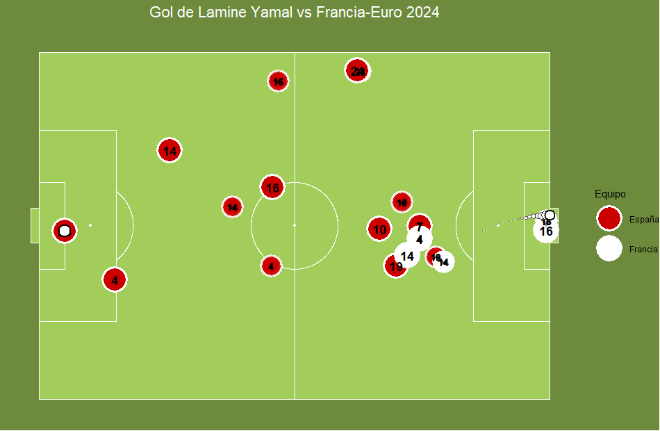

```r
# Generamos el gif
mapa_lamine <- animate(
  animacion_final,
  nframes = total_frames,
  fps = 16,
  width = 950,
  height = 620,
  units = "px",
  res = 100,
  renderer = gifski_renderer("gol_lamine_yamal.gif")
)

mapa_lamine
```

La simulación corrobora que la Selección de Luis de la Fuente dominaba los partidos desde el control del ritmo. El hecho de que la jugada involucre a ocho futbolistas distintos antes del golpeo definitivo, sugiere que el equipo dominaba el juego de posición: madurar la jugada en campo propio hasta que aparezca el hueco necesario en el último tercio.

En definitiva, esta simulación cinemática sirve para demostrar que el éxito de España residió en el equilibrio perfecto entre el orden colectivo y la libertad del talento. Gracias al uso de gganimate hemos podido desglosar un evento de apenas unos segundos para concluir que en el fútbol de élite, los goles memorables son la consecuencia de un sistema posicional perfectamente engrasado.

## 4.4. La Final contra Inglaterra: Dinámica Temporal de Remates y Animación del Gol de Oyarzabal

Si bien en el punto anterior mirábamos el juego desde una perspectiva donde las acciones dejaban un rastro que ayudaba a entender patrones generales, aquí cambiamos de escala. Dejamos de observar el comportamiento global para trasladarnos al partido definitivo ante Inglaterra para evaluar cómo las dinámicas temporales se traducen en éxito deportivo. Para ello, esta sección se divide en dos enfoques complementarios: primero, un estudio cronológico del volumen y peligro de los remates a lo largo de los 90 minutos y en segundo lugar una reconstrucción del gol que valió el campeonato.

El principal reto técnico para mostrar la evolución del partido es gestionar cómo se actualizan los datos en pantalla a medida que pasa el tiempo. Para que la animación funcione bien, no podemos usar los eventos en bruto, sino que necesitamos agruparlos los datos en intervalos de tiempo fijos.

Para resolver esta necesidad, recurrimos a la función transition_states() de gganimate. A diferencia de otras funciones de la librería que buscan suavizar el movimiento de los puntos, aquí se busca segmentar la información en estados independientes definidos por la variable frame_id.

Para lograr el efecto visual deseado, la parametrización de la función es clave. Usamos transition_length = 0, al igualar a cero este argumento se anula por completo la interpolación de los datos entre un minuto y el siguiente. En este caso se elimina cualquier transición fluida en el gráfico mientras que para state_length = 1 se asigna un tiempo relativo de visualización estático para cada estado.

La combinación de ambos parámetros fuerza a la animación a dar saltos discretos e instantáneos. El gráfico renderiza de golpe todos los remates acumulados hasta ese instante cada vez que el reloj cambia, simulando el avance real de los minutos del partido.

Asimismo, para que la animación sea acumulativa, no usamos en este caso funciones como shadow_mark(), en su lugar, se diseña un algoritmo previo mediante un bucle for. Este bucle recorre el partido minuto a minuto duplicando secuencialmente los datos en la tabla final, garantizando que cada nuevo estado contenga toda la información de los minutos anteriores.

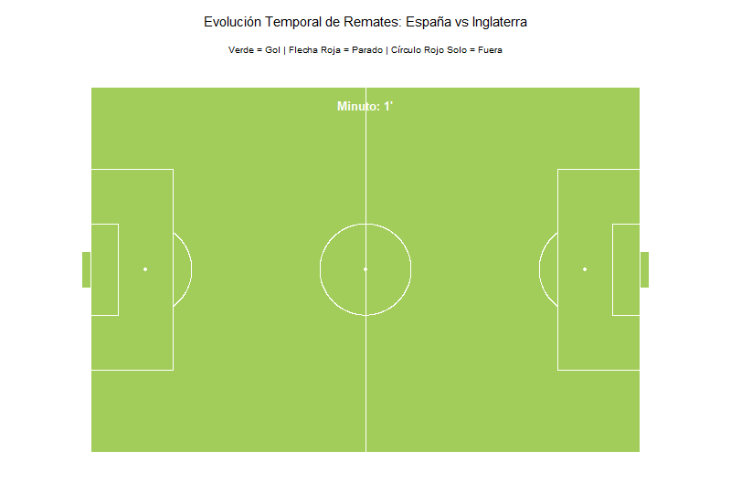

```r
# Importamos nuestro archivo con los datos de todos los remates de la Eurocopa
tiros_brutos <- read.csv("tiros_espana.csv", stringsAsFactors = FALSE)

# Nos quedamos solo con los datos de la final y reorientamos el campo de juego
# Ajustamos las coordenadas para que, visualmente, España ataque siempre hacia la derecha e Inglaterra hacia la izquierda
tiros_limpios <- tiros_brutos %>%
  filter(match_id == 3943043) %>%
  mutate(
    minute     = as.integer(minute),
    x_num      = as.numeric(location_x),
    y_num      = as.numeric(location_y),
    x_ajustada = if_else(team.name == "Spain", x_num, 120 - x_num),
    y_ajustada = if_else(team.name == "Spain", 80-y_num, y_num),
    porteria_x = if_else(team.name == "Spain", 120, 0),
    porteria_y = 40,
    # Clasificamos cada remate en base a su resultado para poder pintarlos de un color diferente más adelante
    categoria_tiro = case_when(
      shot.outcome.name == "Goal"  ~ "Gol (Verde)",
      shot.outcome.name == "Saved" ~ "Parado / A Portería (Rojo)",
      TRUE                         ~ "Fuera / Bloqueado (Rojo)"
    )
  )

# Preparamos una tabla vacía que iremos rellenando con la historia del partido minuto a minuto
cronologia_acumulada <- data.frame()

# Organizamos la línea temporal para que los tiros se vayan quedando fijos en el mapa conforme avanza el partido
# Recorremos el partido minuto a minuto guardando todo lo que ha pasado hasta ese momento para que la animación sea acumulativa
for (m in 1:90) {
  tiros_hasta_ahora <- tiros_limpios %>% filter(minute <= m)

  if (nrow(tiros_hasta_ahora) == 0) {
    # Si en los primeros minutos nadie tira a puerta, creamos un punto invisible lejano para que el gráfico no se rompa
    fila_vacia <- data.frame(
      minute = m, frame_id = m, x_ajustada = -150, y_ajustada = -150,
      porteria_x = -150, porteria_y = -150, categoria_tiro = "Fuera / Bloqueado (Rojo)",
      shot.statsbomb_xg = 0.01, player.name = NA, es_tiro_real = FALSE
    )
    cronologia_acumulada <- bind_rows(cronologia_acumulada, fila_vacia)
  } else {
    # Si hay tiros en ese minuto, los guardamos y les asignamos el momento exacto del partido en el que deben aparecer
    tiros_hasta_ahora <- tiros_hasta_ahora %>%
      mutate(frame_id = m, es_tiro_real = TRUE)
    cronologia_acumulada <- bind_rows(cronologia_acumulada, tiros_hasta_ahora)
  }
}

# Ordenamos toda la historia del partido y preparamos el diseño del reloj superior
cronologia_acumulada <- cronologia_acumulada %>%
  arrange(frame_id) %>%
  mutate(frame_id = factor(frame_id, levels = 1:90)) %>%
  group_by(frame_id) %>%
  # Diseñamos el texto del marcador superior que irá cambiando minuto a minuto
  mutate(
    minuto_numerico = as.integer(as.character(frame_id)),
    etiqueta_reloj  = paste0("Minuto: ", frame_id, "'"),
    # Nos aseguramos de escribir el texto del minuto solo una vez por cada bloque para que el texto no se vea borroso
    es_primera_fila_del_minuto = (row_number() == 1)
  ) %>%
  ungroup() %>%
  # Calculamos la posición exacta de las porterías para poder dibujar las flechas de los tiros que fueron a puerta
  mutate(
    xend_flecha = if_else(es_tiro_real & shot.outcome.name %in% c("Goal", "Saved"), porteria_x, as.numeric(NA)),
    yend_flecha = if_else(es_tiro_real & shot.outcome.name %in% c("Goal", "Saved"), porteria_y, as.numeric(NA))
  )

  # Elegimos los colores estáticos que usaremos para diferenciar los goles de los tiros fallados
colores_esquema <- c(
  "Gol (Verde)"               = "green",
  "Parado / A Portería (Rojo)" = "red",
  "Fuera / Bloqueado (Rojo)"  = "red"
)
verde_cesped <- "darkgreen"
lineas_cal <- "white"

  # Dibujamos el mapa táctico completo recreando un campo de fútbol real
pizarra_animada <- ggplot(cronologia_acumulada) +
  annotate_pitch(dimensions = pitch_statsbomb, fill = "darkolivegreen3", colour = "white") +

  # Pintamos flechas desde la posición inicial hasta la portería para representar los tiros a puerta
  geom_segment(data = filter(cronologia_acumulada, !is.na(xend_flecha)),
               aes(x = x_ajustada, y = y_ajustada, xend = xend_flecha, yend = yend_flecha, color = categoria_tiro),
               arrow = arrow(length = unit(0.14, "cm"), type = "closed"), linewidth = 0.6, alpha = 0.85) +

  # Añadimos los círculos que representan el lugar exacto desde donde chutó cada jugador
  # Hacemos que los círculos sean más grandes o más pequeños dependiendo de lo peligrosa que era la ocasión de gol
  geom_point(data = filter(cronologia_acumulada, es_tiro_real),
             aes(x = x_ajustada, y = y_ajustada, color = categoria_tiro, size = shot.statsbomb_xg), alpha = 0.9) +

  # Aplicamos nuestra paleta de colores para los puntos y controlamos su tamaño
  scale_color_manual(values = colores_esquema) +
  scale_size_continuous(range = c(2, 6)) +

  # Dibujamos en la parte de arriba del césped el texto del reloj para ver los minutos pasar en tiempo real
  geom_text(data = filter(cronologia_acumulada, es_primera_fila_del_minuto),
            aes(x = 60, y = 76, label = etiqueta_reloj),
            color = "white", size = 3.2, fontface = "bold", check_overlap = TRUE) +

  # Encuadramos el campo de fútbol para mantener sus proporciones reales y añadimos los títulos del gráfico
  coord_equal(xlim = c(-2, 122), ylim = c(-2, 82)) +
  labs(
    title = "Evolución Temporal de Remates: España vs Inglaterra",
    subtitle = "Verde = Gol | Flecha Roja = Parado | Círculo Rojo Solo = Fuera"
  ) +
  # Dejamos el fondo del color del césped y cambiamos los títulos a negro y rojo
  theme_void() +
  theme(
    plot.background = element_rect(fill = "white", color = NA),
    plot.title = element_text(color = "black", face = "bold", size = 11, hjust = 0.5, vjust = 2),
    plot.subtitle = element_text(color = "black", face = "italic", size = 7.5, hjust = 0.5),
    legend.position = "none",
    plot.margin = margin(10, 10, 10, 10)
  ) +

  # Le indicamos a la animación que vaya cambiando el dibujo del mapa siguiendo el orden de los minutos del partido
  transition_states(frame_id, transition_length = 0, state_length = 1)

# Procesamos y renderizamos todas las imágenes juntas ajustando el ritmo visual de reproducción final del archivo gif
animacion_final <- animate(
  pizarra_animada,
  nframes   = 120,
  fps       = 5,
  end_pause = 20,
  width     = 800,
  height    = 540,
  units     = "px",
  res       = 100,
  renderer  = gifski_renderer()
)

# Guardamos el mapa animado finalizado directamente en la carpeta de nuestro ordenador
anim_save("mapa_tiros_minuto_a_minuto.gif", animation = animacion_final)

# Imprimimos la animación en la pantalla
animacion_final
```

Como muestra la animación, el inicio del partido se reflejó el clásico respeto mutuo de una final. Inglaterra apenas asomaba con un tiro muy escorado, mientras que España realizaba sus primeros intentos desde media distancia o la frontal, incapaz todavía de romper el bloque bajo inglés para pisar área pequeña.

En el minuto 50’ se observa el punto de inflexión del partido. Tras el descanso, España rompe la simetría con una incursión vertical que culmina en el primer gol del partido. El tamaño del punto refleja una probabilidad media-alta, evidenciando que la jugada se elaboró hasta encontrar una posición cómoda de golpeo dentro del área grande.

Posteriormente, se aprecia cómo Inglaterra se ve obligada a estirar líneas, logrando conectar un disparo cruzado que bate a Unai Simón. Sin embargo, finalmente se aprecia la aparición del segundo punto verde para España. Mientras Inglaterra terminó el encuentro con apenas 4 remates dentro del área, España colonizó por completo la zona de castigo rival con 11 intentos en total.

Como se puede comprobar en el análisis cronológico anterior, el punto de inflexión definitivo que corona a España como campeona se produce en el tramo final del encuentro, materializado en ese segundo círculo verde tras el minuto 85’. Para comprender la naturaleza de ese golpe estratégico, no basta con saber desde dónde se chutó, es necesario aplicar un enfoque táctico para desgranar la jugada. Por tanto, este bloque se conecta directamente con el anterior, pasando de la acumulación de tiros a la reconstrucción de la jugada que desarmó por completo el entramado defensivo de Inglaterra: el gol de Mikel Oyarzabal.

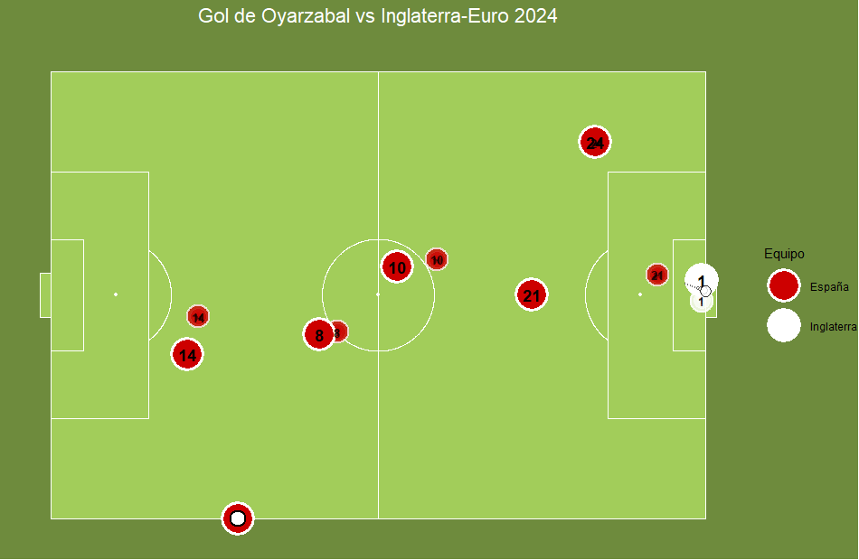

```r
# Usamos una función para generar la trayectoria del balón para cada pase y cada conducción
generar_tramo_balon <- function(x_init, y_init, x_end, y_end, duration) {
  tibble(
    ball_x = seq(x_init, x_end, length.out = duration),
    ball_y = seq(y_init, y_end, length.out = duration)
  )
}

# Generamos las distintas trayectorias (haciendo uso de los datos de nuestra base)
t1  <- generar_tramo_balon(34.3, 0, 25.1, 29.4, duration = 20)  # Carvajal -> Laporte
c1  <- generar_tramo_balon(25.1, 29.4, 27.0, 36.2, duration = 10)
t2  <- generar_tramo_balon(27.0, 36.2, 49.3, 33.0, duration = 18) # Laporte -> Fabián
c2  <- generar_tramo_balon(49.3, 33.0, 52.6, 33.4, duration = 10)
t3  <- generar_tramo_balon(52.6, 33.4, 63.4, 45.1, duration = 16) # Fabián -> Dani Olmo
c3  <- generar_tramo_balon(63.4, 45.1, 70.7, 46.4, duration = 20)
t4  <- generar_tramo_balon(70.7, 46.4, 88.2, 40.1, duration = 16) # Dani Olmo -> Oyarzabal
c4  <- generar_tramo_balon(88.2, 40.1, 88.9, 42.2, duration = 8)
t5  <- generar_tramo_balon(88.9, 42.2, 99.7, 67.3, duration = 20) # Oyarzabal -> Cucurella
c5  <- generar_tramo_balon(99.7, 67.3, 100.0, 67.3, duration = 8)
t6  <- generar_tramo_balon(100.0, 67.3, 111.2, 43.7, duration = 26) # Cucurella -> Oyarzabal

# Generamos la trayectoria del disparo
X_tiro <- seq(111.2, 120.0, length.out = 20)

# El tiro arranca en 43.7 y avanza de forma recta hasta el fondo de la red en 40.7
Y_tiro <- seq(43.7, 40.7, length.out = 20)

t_disparo <- tibble(ball_x = X_tiro, ball_y = Y_tiro)

# Generamos una base de datos adicional con las trayectorias
balon_completo <- bind_rows(
  t1, c1, t2, c2, t3, c3, t4, c4, t5, c5, t6, t_disparo
) %>% mutate(frame_id = row_number())

# Usamos una variable auxiliar para saber los frames que necesitaremos en nuestro  gif
total_frames <- nrow(balon_completo)

# Según la duración designada para cada evento generamos una variable auxiliar para luego usarlo para representar las conducciones de los jugadores
f_t1  <- 20;          f_c1  <- f_t1 + 10; f_t2  <- f_c1 + 18;  f_c2  <- f_t2 + 10
f_t3  <- f_c2 + 16;   f_c3  <- f_t3 + 20; f_t4  <- f_c3 + 16;  f_c4  <- f_t4 + 8
f_t5  <- f_c4 + 20;   f_c5  <- f_t5 + 8;  f_t6  <- f_c5 + 26

# Creamos una función para obtener la posición de los jugadores
obtener_posiciones_jugadores <- function(f) {
  # Generamos la posición inicial de cada jugador español
  espana <- tibble(
    no = c("2", "14", "8", "10", "21", "24"),
    x  = c(34.3, 25.1, 49.3, 63.4, 88.2, 99.7),
    y  = c(0.0, 29.4, 33.0, 45.1, 40.1, 67.3),
    team = "España"
  )
  # Nuestra idea basicamente es que cada jugador se vaya moviendo conduciendo el balón cuando vayan a realizar un pase desde donde reciba el balón hasta donde dé el pase y se mueva también cuando tenga que recibir un pase en un lugar distinto al que está, para esto echamos mano de las variables anteriormente generadas f_t para así poder generar el movimiento en el momento adecuado, ya sea cuando reciba el pase para conducir o cuando acabe de darlo para ir a recibir el siguiente pase. Usaremos una variable auxiliar, pct para generar números entre 0 y 1 para que así el movimiento sea continuo, desde que da el pase hasta que lo reciba y el jugador no se quede quieto en ningún momento.

  # Generamos el movimiento de Laporte
  if (f <= f_t1) {
    espana$x[espana$no == "14"] <- 25.1; espana$y[espana$no == "14"] <- 29.4
  } else if (f > f_t1 && f <= f_c1) {
    espana$x[espana$no == "14"] <- balon_completo$ball_x[f]; espana$y[espana$no == "14"] <- balon_completo$ball_y[f]
  } else{
    espana$x[espana$no == "14"] <- 27.0 ; espana$y[espana$no == "14"] <- 36.2
  }
  # Generamos el movimiento de Fabián
  if (f <= f_t2) {
    espana$x[espana$no == "8"] <- 49.3; espana$y[espana$no == "8"] <- 33.0
  } else if (f > f_t2 && f <= f_c2) {
    espana$x[espana$no == "8"] <- balon_completo$ball_x[f]; espana$y[espana$no == "8"] <- balon_completo$ball_y[f]
  } else {
    espana$x[espana$no == "8"] <- 52.6 ; espana$y[espana$no == "8"] <- 33.4
  }

  # Generamos el movimiento de Dani Olmo
  if (f <= f_t3) {
    espana$x[espana$no == "10"] <- 63.4; espana$y[espana$no == "10"] <- 45.1
  } else if (f > f_t3 && f <= f_c3) {
    espana$x[espana$no == "10"] <- balon_completo$ball_x[f]; espana$y[espana$no == "10"] <- balon_completo$ball_y[f]
  } else {
    espana$x[espana$no == "10"] <-70.7 ; espana$y[espana$no == "10"] <- 46.4
  }

  # Generamos el movimiento de Oyarzabal
  if (f <= f_t4) {
    espana$x[espana$no == "21"] <- 88.2; espana$y[espana$no == "21"] <- 40.1
  } else if (f > f_t4 && f <= f_c4) {
    espana$x[espana$no == "21"] <- balon_completo$ball_x[f]; espana$y[espana$no == "21"] <- balon_completo$ball_y[f]
  } else if (f>f_c4 && f<=f_t6){
    pct<-(f-f_c4)/(f_t6-f_c4)
    espana$x[espana$no == "21"] <- 88.9+(111.2-88.9)*pct; espana$y[espana$no == "21"] <- 42.2+(43.7-42.2)*pct
  } else{
    espana$x[espana$no == "21"]<-111.2; espana$y[espana$no == "21"]<-43.7
  }

  # Generamos el movimiento de Cucurella
  if (f <= f_t5) {
    espana$x[espana$no == "24"] <- 99.7; espana$y[espana$no == "24"] <- 67.3
  } else if (f > f_t5 && f <= f_c5) {
    espana$x[espana$no == "24"] <- balon_completo$ball_x[f]; espana$y[espana$no == "24"] <- balon_completo$ball_y[f]
  } else {
    espana$x[espana$no == "24"] <- 100.0; espana$y[espana$no == "24"] <- 67.3
  }

  # Movimiento de Pickford intentando adivinar el tiro
  mx <- 119.2
  y_inicial_pickford <- 42.6
  y_final_pickford <- 39.0

  my <- y_inicial_pickford

  # Empieza a moverse justo cuando Oyarzabal chuta, hasta que termina la animación (total_frames)
  if (f >= f_t6) {
    pct_e <- min((f - f_t6) / (total_frames - f_t6), 1)

    my <- y_inicial_pickford + (y_final_pickford - y_inicial_pickford) * pct_e
  }

  inglaterra_pickford <- tibble(no = "1", x = mx, y = my, team = "Inglaterra")

  # Añadimos las posiciones y el movimiento de los jugadores
  bind_rows(espana, inglaterra_pickford) %>% mutate(frame_id = f)
}

# Generamos una variable con las posiciones de los jugadores en cada frame
jugadores_completo <- map_df(1:total_frames, obtener_posiciones_jugadores)
# Añadimos a la base de datos esta variable teniendo así juntas la posición del balón y de cada jugador
datos_maestros <- jugadores_completo %>% left_join(balon_completo, by = "frame_id")

# Generamos el gráfico
plot_sistema <- ggplot(datos_maestros) +
  # Le damos imagen de campo de fútbol al gráfico
  annotate_pitch(dimensions = pitch_statsbomb, fill = "darkolivegreen3", colour = "white") +
  # Añadimos los jugadores, números, colores a cada equipo y el balón
  geom_point(aes(x = x, y = y, fill = team), shape = 21, size = 11, stroke = 1.8, color = "white") +
  geom_text(aes(x = x, y = y, label = no), color = "black", fontface = "bold", size = 4.5) +
  scale_fill_manual(values = c("España" = "red3", "Inglaterra" = "white")) +
  geom_point(aes(x = ball_x, y = ball_y), shape = 21, fill = "white", color = "black", stroke = 1.3, size = 5.2) +
  # Añadimos el título y el nombre de la leyenda
  labs(
    title = "Gol de Oyarzabal vs Inglaterra-Euro 2024",
    fill="Equipo"
  ) +
  # Definimos los límites de x e y algo superiores a  las medidas del campo para no cortar el balón cuando entre en la portería
  xlim(-3, 123) + ylim(-3, 83) +
  # Eliminamos los elementos típicos de ggplot
  theme_void() +
  # Pintamos el exterior del campo para que sea más visual y damos estilo al texto del título
  theme(
    plot.title = element_text(face = "bold", size = 16, hjust = 0.5, color = "white", vjust = 1),
    plot.background = element_rect(fill = "darkolivegreen4", color = NA)
  )

# Generamos la animación con las funciones explicadas de gganimate
animacion_final <- plot_sistema +
  transition_states(frame_id, transition_length = 1, state_length = 0, wrap = FALSE) +
  ease_aes('linear') +
  view_follow(fixed_x = TRUE, fixed_y = TRUE) +
  shadow_wake(wake_length = 0.05, alpha = 0.2, exclude_layer = c(1, 2))

# Generamos el gif
mapa_oyarzabal <- animate(
  animacion_final,
  nframes = total_frames,
  fps = 16,
  width = 950,           # 950 píxeles
  height = 620,          # 620 píxeles
  units = "px",
  res = 100,             # Resolución de pantalla estándar optimizada
  renderer = gifski_renderer("gol_oyarzabal.gif")
)

mapa_oyarzabal
```

La animación refleja de manera impecable el concepto de “tercer hombre” y la gestión del espacio. Este evidencia cómo la rápida circulación interior entre Fabián y Dani Olmo obliga al bloque inglés a bascular y hundirse en su propia área. Esto genera una ventaja espacial en el flanco izquierdo que Cucurella aprovecha para recibir libre de marca y ejecutar un centro raso quirúrgico.

Esta secuencia geométrica culmina con una perfecta sincronización por parte de Oyarzabal, quien no solo activa la jugada, sino que traza una carrera diagonal milimétrica para atacar el área pequeña en el instante preciso del centro. La simulación gráfica del vector de disparo y el desplazamiento de Pickford muestran como la anticipación del delantero español y la velocidad de ejecución baten la capacidad de reacción del guardameta inglés, materializando de este modo el gol que definió la final.

# 5. Conclusión

El análisis de datos detallado en este documento nos permite garantizar que el éxito de la Selección Española en la Eurocopa 2024 no fue producto de la casualidad o de la mera fortuna deportiva, sino la consecuencia lógica de una superioridad táctica y colectiva contrastable estadísticamente. A través del procesamiento de las métricas clave de rendimiento, se ha podido cuantificar cómo ‘La Roja’ consiguió imponer su identidad de juego en cada uno de los encuentros. Desde el control de la posesión hasta la efectividad de cara a la portería contraria, las variables analizadas configuran el retrato de un equipo que dominó las distintas facetas del juego, justificando su posición en la cima del torneo continental.

El valor metodológico de este trabajo reside en su capacidad para ir más allá de la crónica deportiva convencional, traduciendo el rendimiento del campo al lenguaje preciso de los datos. La implementación de la programación y la manipulación de bases de datos mediante librerías analíticas ha permitido estructurar, filtrar y ponderar la información de una forma robusta. Este enfoque riguroso no solo valida el relato de los analistas, sino que aporta una capa de objetividad científica que resulta indispensable en el fútbol moderno, donde la toma de decisiones estratégicas se apoya cada vez más en la evidencia cuantitativa.

Asimismo, la representación gráfica se ha consolidado como el pilar fundamental para la comprensión de estas situaciones sobre el campo. La conversión de registros y tablas densas en visualizaciones dinámicas, mapas de calor y gráficos comparativos permite contrastar al instante el rendimiento de España frente al de sus rivales. Estas herramientas visuales no solo facilitan la asimilación del volumen de datos para cualquier lector, sino que revelan patrones y tendencias del juego que a menudo pasan desapercibidas en el simple visionado de los partidos.

En definitiva, este proyecto ejemplifica la perfecta sinergia que existe actualmente entre las ciencias de datos y el deporte de alto rendimiento. Al terminar esta investigación, queda de manifiesto que las herramientas digitales y los lenguajes de programación no son ajenos a la pasión del fútbol, sino que actúan como la mejor herramienta disponible para desgranarla. El dominio de España en la Eurocopa 2024 queda así inmortalizado no solo en las vitrinas de trofeos, sino también en las líneas de código gracias a las estadísticas que definieron un torneo perfecto. Si los datos siguen de nuestra parte, la segunda estrella será nuestra este verano.